# **Focusing on Women’s Issues in STEM through Reddit Data**

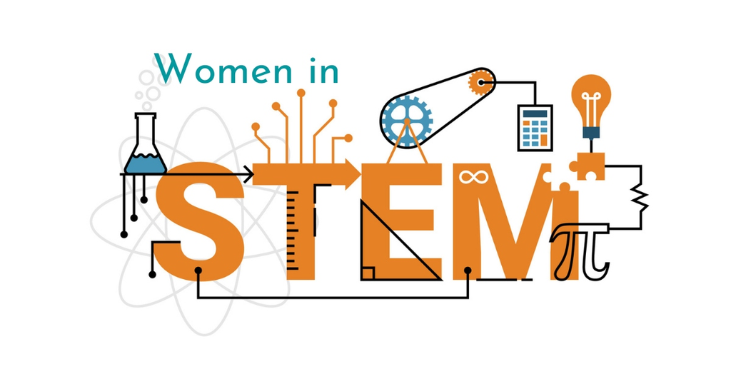

# **Background**

This project springs from the history of how genders are represented in the world of Science, Technology, Engineering, and Mathematics (STEM). These areas have been led by men in the past, causing a lack of women and other gender minorities. The gender gap has many repercussions. It impacts the office atmosphere and the focus of research and innovation. Let’s elaborate on this context:

1. **Past Lack of Diversity**: STEM areas have typically had fewer females and gender minorities. This is linked to different factors such as societal labels, not enough mentors, and barriers in education and jobs. We understand present difficulties and the necessity for change better by looking at history.
2. **Altering Views and Actions**: Lately, an evident move towards acknowledging and tackling the gender disparity in STEM has been seen. This shift is propelled by both ground level support and system wide actions. Measures include encouraging STEM learning among girls, setting up guidelines for gender fairness in work areas, and escalating the representation of women and gender minorities in these domains.
3. **Conversations over the Internet**: Websites like Reddit play a key role in grasping public chat about matters. These sites give pure looks into people’s views, life happenings, and mindset. The mystery and broadness of web spaces open a variety of viewpoints. You can find input from STEM insiders and outsider’s perspectives. This all compounds to form a rich tapestry of public conversation.
4. **Unveiling Struggles**: Often, online talks point out the persisting problems encountered by women and those with different gender identities in STEM. These talk about instances of bias and prejudice, obstacles in career growth, and struggle in balancing work and life. Open chats like these give true life instances of the hurdles present despite the progress we’ve made.
5. **Monitoring Shifts and Changes**: These tools also act as thermometers for detecting societal changes in views related to STEM gender diversity. Uplifting accounts of triumph and encouragement, policy debates, and conversations about diversity’s role in sparking innovation signal shifts in understanding.
6. **Shaping Rules and Social Progress:** Talks on websites like Reddit can mirror public perspectives and even affect them. These discussions can alert rule makers, teachers, and trade chiefs about real life situations, assisting in creating better and all encompassing rules and actions.

# **Objective**

This project centers around a detailed look at conversation about women and gender minorities in STEM areas. Specifically, it looks at Reddit discussions. Among the main goals and topics we want to explore are:

1. **Understanding Representation**: Grasping how females and gender minorities get a spotlight in STEM related subreddit conversations is the key objective. This involves how conversations revolve in this domain. To see if they get an equal and respectful shout out, and to spot any trends showing them as being a minority or misrepresented.
2. **Spotting Roadblocks**: A key piece of our task involves uncovering the unique challenges met by women and those of different genders in STEM within the Reddit community’s discussions. This could encompass topics like workplace gender prejudice, obstacles in climbing the career ladder, issues balancing work and personal life, as well as experiences of prejudice or harassment. Knowing these obstacles is vital for creating ways to defeat them.
3. **Examining Thoughts and Feelings:** This project aims to review feelings around women and gender minorities in STEM. We apply NLP methods to judge if conversations are mostly positive, negative, or neutral. We can then understand the general views of these groups in the STEM community.
4. **Assessing Participation from the Community:** We aim to identify the level of Reddit community’s involvement in STEM related gender issues through aspects like how often posts or comments are made and the degree of user contribution. This might reveal how interested and concerned the community members are about these subjects.
5. **Expanding Awareness of Gender Interactions:** The results of our study add to the wider comprehension of gender interactions within STEM disciplines. Offering an in depth view of present conversations surrounding women and gender minorities in STEM, the investigation serves to update scholars, industry workers, and policy creators on established viewpoints and difficulties. This critical information helps shape rules, actions, and educational plans endorsing diversity and inclusiveness within STEM sectors.
6. **Guiding Future Studies and Moves:** This research’s findings can pave the way for future studies and actions. They can spotlight lesser known topics or emerging trends. These can steer more scholarly research, raise awareness, and aid in making laws to boost gender fairness in STEM.

[figure not shown]

# **Data Collection**

### **Reddit Data:**

Gathering our Reddit dataset involved meticulous effort and clear focus. We aimed to collect a complete and relevant set of data reflecting the experiences, voices, and views of women and gender minorities in STEM fields. We zeroed in on specific subreddits known for active conversations on these subjects. The subreddits are: “xxstem”, “LadiesofScience”, “Feminism”, “womenEngineers”, “AskFeminists”, and “AskWomen”.

1. **xxstem**: It is specifically for conversations about women and non binary people in the STEM world. It’s a spot for sharing experiences, hurdles, and wins. The posts usually consist of personal journeys, tips on maneuvering through STEM careers, and deliberations on boosting gender diversity and inclusivity in these areas.
2. **LadiesofScience**: A group dedicated to women in science, engineering, and research roles. It acts as a hub for encouragement, swapping stories, and tackling the unique hurdles women meet in their scientific professions. Subjects cover professional growth, juggling work life duties and confronting gender prejudice in the field of science.
3. **Feminism**: This forum often touches on gender equality topics, and many conversations center around women in STEM. This space is ideal for talking about deep set problems, pushing for improvements in laws, and sharing updates about women’s rights and equal opportunities. A good chunk of it investigates hurdles and advancements in STEM areas.
4. **womenEngineers**: This dedicated subreddit aims at women and their unique journey in the engineering segment of the STEM domain. It offers a platform where advice on careers can be shared, discussions on work environment are encouraged, and it spotlights the challenges and victories experienced by women engineers.
5. **AskFeminists**: This online community gives you a space to ask questions related to feminist thoughts and ideologies. It specifically examines STEM topics from a feminist angle. The discussion points include gender difference in STEM education and jobs, the influence of gender prejudice in scientific studies, and methods to obtain gender balance in STEM areas.
6. **AskWomen**: A varied chatroom that touches on many subjects from a woman’s viewpoint, including STEM related ones. This web forum frequently shares personal stories about life in STEM, conversations about managing work and personal time, and views on the atmosphere in STEM fields. This offers a rich blend of perspectives on women’s daily encounters in different aspects of life, including their parts in STEM.

[figure not shown]

### **External data:**

The NSF’s website on “Diversity and STEM: Women, Minorities, and Persons with Disabilities 2023” shares key information and figures on the active involvement and presence of these groups in scientific and engineering domains. It casts light on areas like education achievements, job status, and degree specialization for women, minorities, and disabled persons. The rich and illuminating data set reveals the ongoing situation of diversity in STEM, underscoring the strides made and the disparities still requiring attention.

# **Significance**

The importance of this project isn’t just about gathering and analyzing data. It’s a significant move to comprehend and tackle complex matters related to gender representation in STEM areas. By studying chats and feelings expressed on social media, especially Reddit, we’re connecting to a resourceful and raw outlet of the public’s thoughts and individual experiences. This method provides multiple important advantages:

1. **Instant Feedback on Existing Sentiments**: Social media works as a live hub where people share personal ideas, experiences, and worries. By studying details from platforms, such as Reddit, we can sense the present thoughts and discussions related to women and gender minorities in STEM. This immediate feedback is crucial for grasping the changing scenario of gender representation in these fields.
2. **Clear Choices for Involved Parties**: This research study’s results can be a fact supported manual for educators, lawmakers, and champions seeking equal gender representation in STEM. By grasping the hurdles, triumphs, and overall opinions of the community, these parties can design more successful tactics and laws. For instance, learning centers can apply this understanding to construct courses and aid systems that include and are mindful of the needs of minor represented factions.
3. **Boosting the Murmurs of Women and Gender Minorities**: The enterprise provides a stage to the murmurs of women and gender minorities in STEM. These voices are not always heard in typical conversations. Placing these narratives in the spotlight, the enterprise shines a light on their journey. It also emphasizes the exclusive difficulties they encounter. This may direct to a more sympathetic and supportive atmosphere in STEM sectors.
4. **Driving Actions to Boost Gender Diversity:** The study can spot certain zones where gender diversity is scarce and expose root issues, like prejudices or institutional blockages. Knowing this is key in creating focused actions to encourage inclusion and diversity in science and technology fields.
5. **Boosting Community Participation and Assistance**: Knowing the ins and outs of online communities talking about STEM and gender matters lets advocates and educators better interact with these groups. This involvement can help cultivate a welcoming setting. It encourages not only women, but also gender minorities, to chase and keep up careers in STEM.
6. **Monitoring Improvement Periodically**: This endeavor can act as a standard for tracking advancement in the portrayal of women in STEM fields. By routinely scrutinizing online chats, interested parties can observe shifts in feelings and representation over time. This gives them a more definite idea of how their work impacts and allows strategy modification when required.

[figure not shown]

# **Business Goals**

## **Exploratory Data Analysis Business Goals:**

**Topic 1: Subreddit Counts**

**Business Goal**: Gain insights into user engagement by understanding the frequency of posts and comments in subreddits of choice.

**Technical Proposal**: To extract data on submissions and comments from subreddits of interest. Perform descriptive statistical analysis to quantify the user interactions for each subreddit.

**Topic 2: Identifying Core Contributors in STEM Discussions**

**Business Goal:** Find the authors who are most active and important in conversations about women in the fields of Science, Technology, Engineering, and Math. These voices matter!

**Technical Proposal:** to identify leading contributors in both submissions and comments datasets. Then, merge the datasets. By using data grouping methods, to find the authors contributing highly to both comments and submissions data.

**Topic 3: Length Statistics**

**Business Goal:** Analyze user engagement on the subreddits by measuring the length of text in comments and submissions.

**Technical proposal:** To obtain the Minimum, Maximum, Average, Median and Standard Deviation values of the “body” column in the comments data set and “title” column in the submissions data set.

**Topic 4: Analysis of Peak Activity Times**

**Business Goal:** Aim to analyze the patterns for STEM related subreddits for discussion over time across various subreddits.

**Technical Proposal:** To use time-series chart to show the frequency of comments and submissions in each subreddit showing the volume of discussions over time. Additionally, to plot day wise and hour wise charts of submissions and comments data to showcase peak activity periods by analyzing post and comment time stamps.

**Topic 5: Subreddit Engagement Comparison**

**Business Goal:** Compare the level of activity and engagement across various subreddits to understand where discussions on women’s issues in STEM are taking place.

**Technical Proposal:** To group and aggregate the number of comments per submission by subreddit and visualize histograms for each subreddit to showcase the frequency of discussions and popularity of each subreddit.

**Topic 6: Issues Faced by Women in STEM**

**Business Goal:** To understand the difficulties that women encounter in the field of STEM, as witnessed in online subreddit conversations.

**Technical Proposal:** To implement regular-pattern structures to identify topics such as Office Discrimination, Equality of Gender, and Health Services in comments and submissions data. To track the percentage of each category and visualize each issue as a pie-chart diagram.

## **Natural Language Processing Business Goals:**

**Topic 7: Topic Popularity**

**Business Goal:** Identify the interests based on Reddit Discussions of Women in STEM.

**Technical Proposal:** To leverage Natural Language Processing techniques to analyze comments and submissions from subreddits after data pre-processing. To create word frequency tables and word clouds to identify the most frequently discussed topics in subreddits in regard to women in STEM.

**Topic 8: Common Challenges Highlighted**

**Business Objective**: Determine the obstacles encountered by women in STEM based on conversations.

**Technical Proposal**: To use TF-IDF (Term Frequency-Inverse Document Frequency) to spot repeating patterns about problems and improve how we pick keywords. It will enhance the specificity of keyword extraction, ensuring that common but non-important words are weighted lower than more important words that are likely to be related to the struggles faced by women in STEM.

**Topic 9: Comparative Sentiment Analysis on Comments**

**Business Goal**: Check the overall feeling (good, bad, or neutral) of the remarks in the chosen subreddits, employing various sentiment analysis models.

**Technical Proposal**: To carry out sentiment analysis on the body of comments from the subreddits related to Women in STEM. To apply three sentiment analysis models namely, IMDb, Vivek, and Twitter, to analyze the sentiments. After applying these models, compare the sentiment scores obtained from each model.

## **Machine Learning Business Goals:**

**Topic 10: Machine Learning to Predict Discussion Popularity**

**Business Goal**: Use predictive modelling to estimate the popularity of subreddit submissions by their scores based on the textual content of its text.

**Technical Proposal**: To deploy regression-based machine learning models like Linear Regression, Random Forest, Gradient Boosting Regressors, and Decision Trees models to predict the score of subreddit submissions.The feature set for these models will be derived from the textual content of the submission titles and self-text column, utilizing NLP techniques for pre-processing and feature extraction. To evaluate the models, we will use Root Mean Square Error (RMSE) and R-square (R²) scores and determine the best model.

**Topic 11: Text Classification for Subreddit Prediction**

**Business Goal:** Use machine learning models to classify submissions based on their textual content into subreddits of interest.

**Technical Proposal**: To use supervised machine learning techniques for text classification. To deploy models like Logistic Regression, Random Forest, Naive Bayes and Decision Trees for training and evaluating the subreddits by metrics like Accuracy, Recall, F1-Score and Precision.

**Topic 12: Common Themes using Clustering**

**Business Goal**: To find out the main themes in the “xxstem” comments subreddit. By doing this, we can understand what topics and interests the community values most.

**Technical Proposal**: To use two grouping systems: KMeans and Hierarchical Clustering. Post-clustering, we’ll evaluate the quality of our clusters using the Silhouette Score to compare the results.

### **Project Contributors**

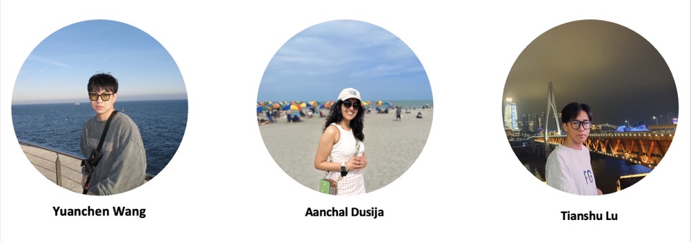